### SDS348/385 Discussion 2

**Jan 28, 2015**

The library ggplot2 is a very powerful resource in R for creating high-quality figures and plots. The basic anatomy of creating a ggplot object is `ggplot(<data_frame>, aes(...)) + geom_<my_geom>()`. Each ggplot object should begin with the function `ggplot()`. Provide the name of your data frame as your first argument and specify aesthetics (which map to your data set!) in the aes() argument. Next, add (with `+`) a particular geom to this ggplot function to specify the type of plot. Note that the initial call to `ggplot()` sets up a plotting environment, and extra additions with `+` will add more layers onto the foundation set up during the call to `ggplot()`. In other words, any arguments you provide to `ggplot()` will hold for all subsequent geoms, facets, etc.

Here, we’ll make some basic ggplot figures using the Ramburii damselfly dataset. R is able to download datasets from the internet simply from the command `read.csv`, so we’ll download/load the data set, as well as the ggplot2 library.

```r
library(ggplot2)
damsel <- read.csv("http://wilkelab.org/classes/SDS348/2015_spring_discussions/ramburii.csv")
head(damsel)
```

```
##   Location Island    Sex Morph Wing_centroid_pixels Mating_status
## 1      ANA    KAU female  gyno             2179.579         wheel
## 2      ANA    KAU   male  male             1987.884         wheel
## 3      ANA    KAU female  gyno             2093.295         alone
## 4      ANA    KAU   male  male             2028.680         alone
## 5      ANA    KAU   male  male             1876.449         wheel
## 6      ANA    KAU female  gyno             2266.906         wheel
##   Abdomen_length_mm
## 1          23.96366
## 2          25.00824
## 3          24.09017
## 4          25.56107
## 5          22.82520
## 6          25.39681
```

### Scatterplots

To begin, make a simple scatterplot of abdomen length vs. centroid wing pixels.

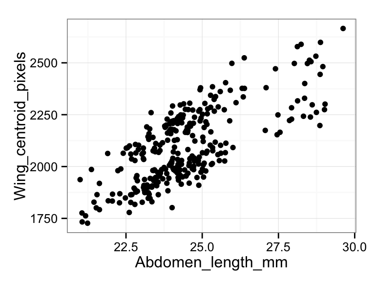

```r
# Create a ggplot object for a scatterplot (geom_point)
ggplot(damsel, aes(x = Abdomen_length_mm, y = Wing_centroid_pixels)) + geom_point()
```

Note that these ggplot objects can be saved to variables to avoid retyping the basic plot over and over (although saving to variables is not required!)

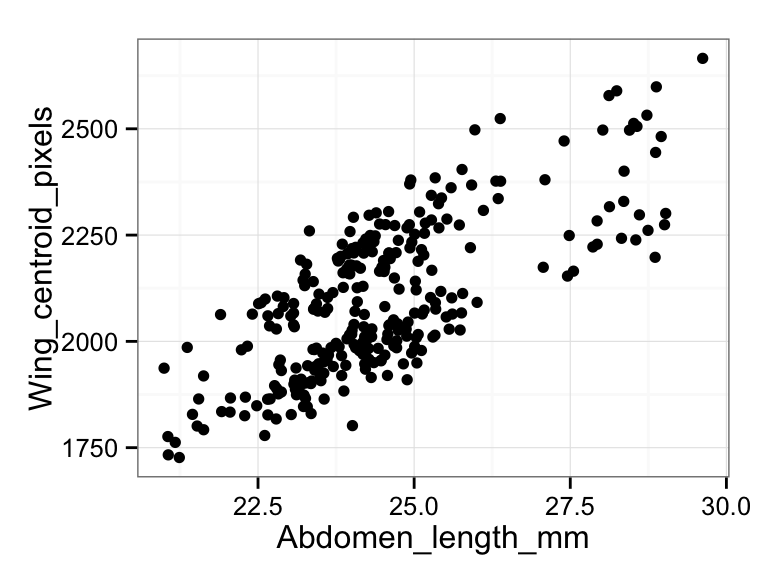

```r
# Create a ggplot object for a scatterplot (geom_point) and save to variable, plot1
plot1 <- ggplot(damsel, aes(x = Abdomen_length_mm, y = Wing_centroid_pixels)) + geom_point()
# Display the plot by entering the variable name
plot1
```

We can easily color points based on other columns in the data frame.

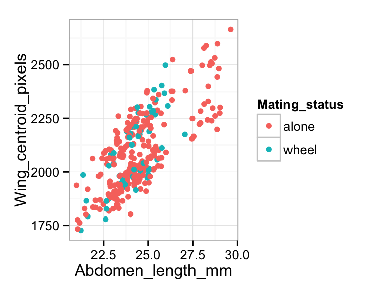

```r
# Include colors for geom_point with the "color" argument
ggplot(damsel, aes(x = Abdomen_length_mm, y = Wing_centroid_pixels, color = Mating_status)) + geom_point()
```

Maybe ggplot’s default colors aren’t to your liking, so you can override the default color scheme as follows.

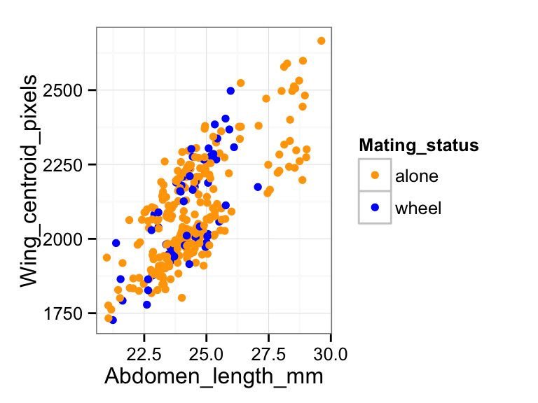

```r
# Add on the command scale_color_manual(values=c(...)) to define custom colors for discrete scales
ggplot(damsel, aes(x = Abdomen_length_mm, y = Wing_centroid_pixels, color = Mating_status)) + geom_point() + scale_color_manual(values=c("orange", "blue"))
```

You can also automatically resize points using the aesthetic `size`.

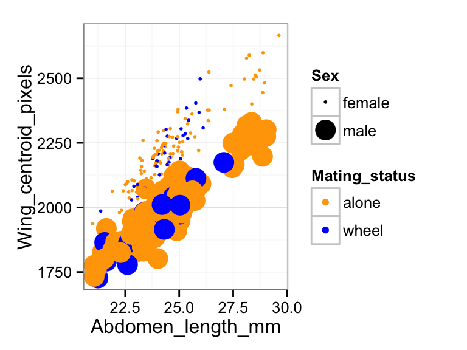

```r
# Set point size based on Sex
ggplot(damsel, aes(x = Abdomen_length_mm, y = Wing_centroid_pixels, color = Mating_status, size = Sex)) + geom_point() + scale_color_manual(values=c("orange", "blue"))
```

As you may notice, the automatic point sizes that ggplot provided are a little nuts. A bit of google searching, however, tells us that we can use the command `scale_size_manual(values=c(...))` to manually set these sizes.

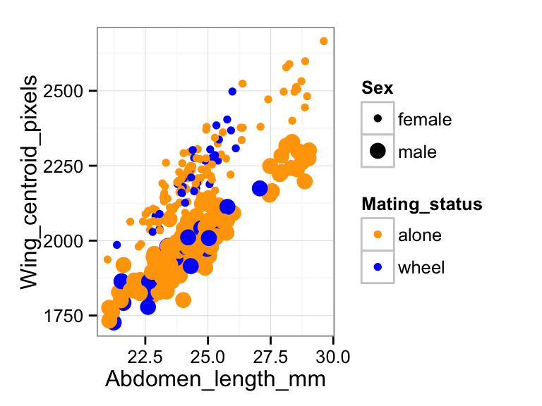

```r
# Set point size based on Sex. Female points will be size 2, and male points will be size 4 (alphabetically assigned!)
color_plot <- ggplot(damsel, aes(x = Abdomen_length_mm, y = Wing_centroid_pixels, color = Mating_status, size = Sex)) + geom_point() + scale_color_manual(values=c("orange", "blue")) + scale_size_manual(values=c(2,4))
color_plot
```

We can also customize the axis labels and add on a title. Either of the two ways given below will work - in general, as long as your code accomplishes the task at hand, you can choose any (within reason) coding strategy!

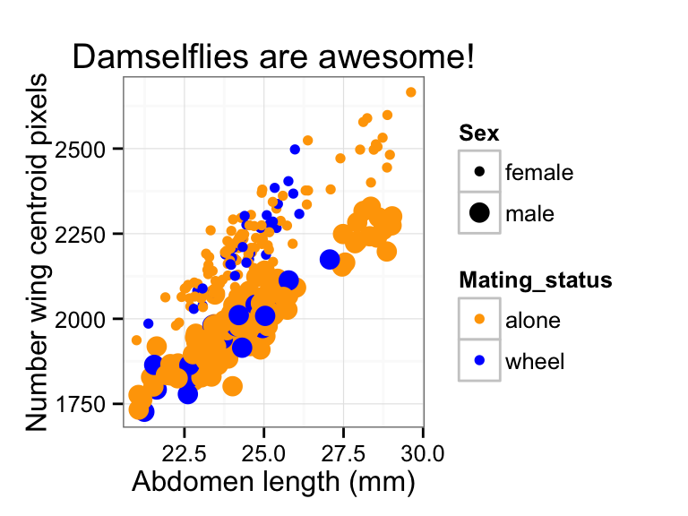

```r
# Use a single command "labs" for all labeling
color_plot + labs(x = "Abdomen length (mm)", y = "Number wing centroid pixels", title = "Damselflies are awesome!")
```

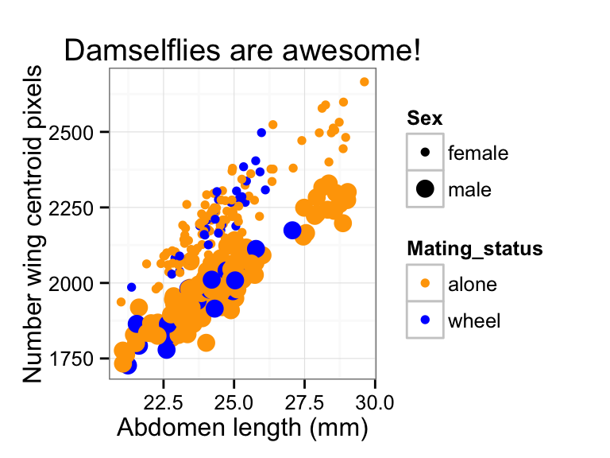

```r
# Use separate commands for each label
color_plot + xlab("Abdomen length (mm)") + ylab("Number wing centroid pixels") + ggtitle("Damselflies are awesome!")
```

### Histograms

As an example for a plot not seen in class, let’s make a histogram using the aptly named geom, `geom_histogram`. Remember, histograms are made with a single numeric variable.

```
## stat_bin: binwidth defaulted to range/30. Use 'binwidth = x' to adjust this.
```

```
## Warning: position_stack requires constant width: output may be incorrect
```

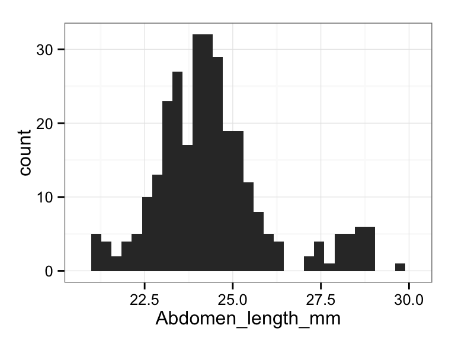

```r
ggplot(damsel, aes(x = Abdomen_length_mm)) + geom_histogram()
```

You’ll notice that R gave us a few warnings - in general, warnings are fine, just a sign that something in your code could be tweaked. Even so, the code was still properly executed. Errors, on the other hand, indicate that your code was simply wrong and not executed at all. Here, we’ve been warned about the “binbreaks,” the size of each bin in the histogram. ggplot’s default breaks may not play nicely with our data, so we can resize them, as the warning indicates, with the argument `binwidth`.

```
## Warning: position_stack requires constant width: output may be incorrect
```

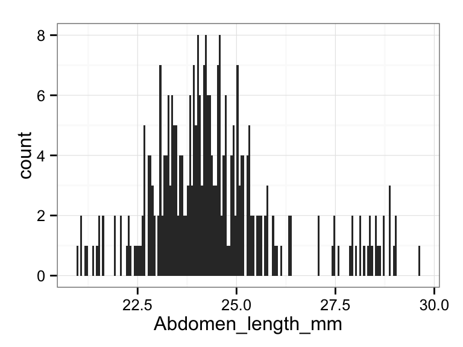

```r
# Use really tiny bins
ggplot(damsel, aes(x = Abdomen_length_mm)) + geom_histogram(binwidth = 0.05)
```

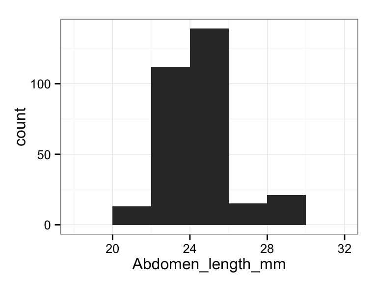

```r
# Use really big bins
ggplot(damsel, aes(x = Abdomen_length_mm)) + geom_histogram(binwidth = 2)
```

We can include colors in histogram using the `fill` argument (not the color argument, as we used in `geom_point`!). In general, `color` will set the outline color, and `fill` will set the internal color. However, as these colors are not mapping to specific date frame columns, they *do not belong in as* `aes()` *arguments*.

```
## stat_bin: binwidth defaulted to range/30. Use 'binwidth = x' to adjust this.
```

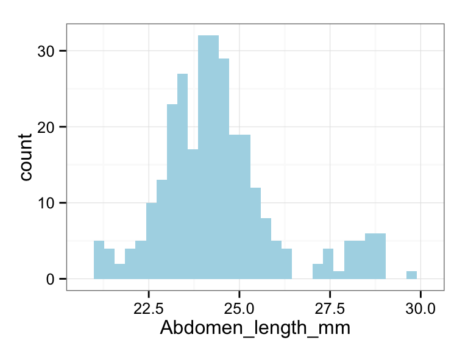

```r
# Use just fill
ggplot(damsel, aes(x = Abdomen_length_mm)) + geom_histogram(fill = "lightblue")
```

```
## stat_bin: binwidth defaulted to range/30. Use 'binwidth = x' to adjust this.
```

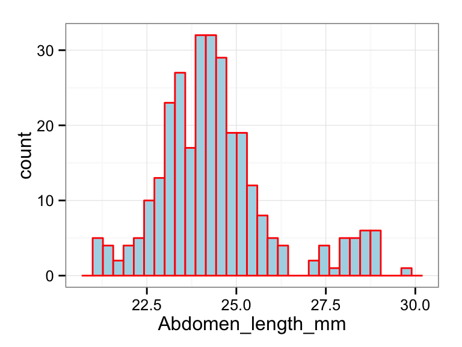

```r
# Use color and fill
ggplot(damsel, aes(x = Abdomen_length_mm)) + geom_histogram(fill = "lightblue", color = "red")
```